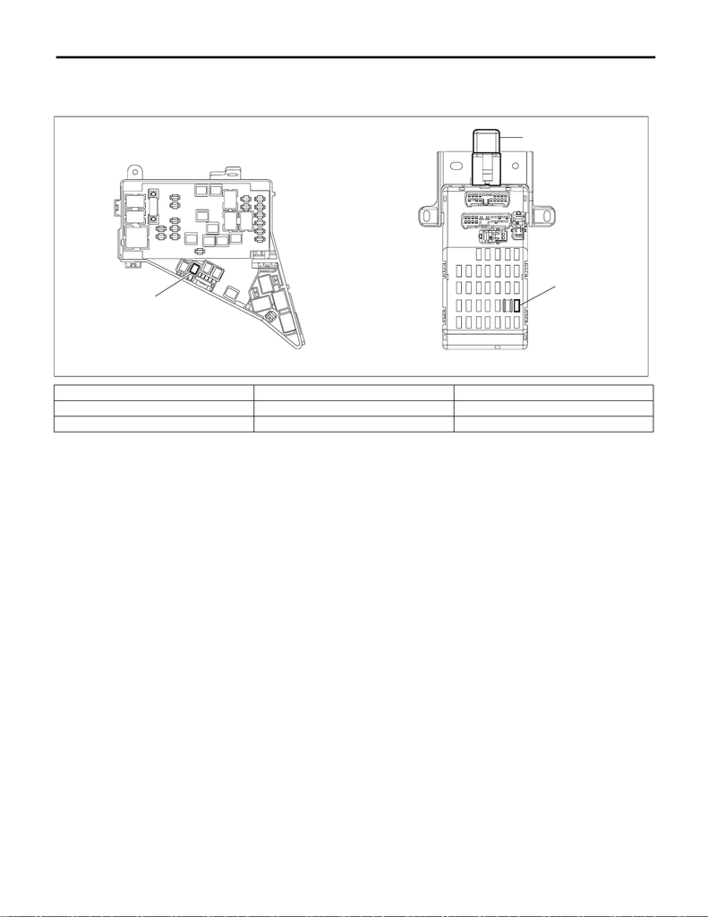

WW-5

Relay and Fuse

WIPER AND WASHER SYSTEMS

2. Relay and Fuse

A: LOCATION

NOTE:

For other related fuses, refer to the wiring diagram. <Ref. to WI-28, Power Supply Circuit.>

Main fuse box Fuse 30 A (wiper) (A)

Relay & fuse box Fuse 7.5 A (wiper) (B)

Relay holder Wiper relay (C)

WW-01199

(B)

(A)

(C)

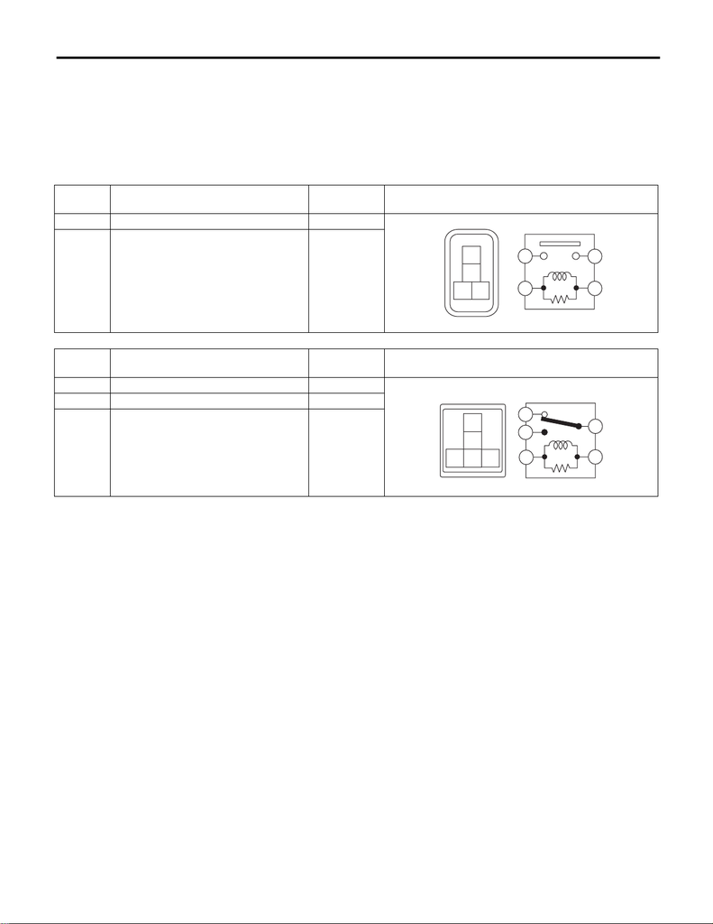

WW-6

Relay and Fuse

WIPER AND WASHER SYSTEMS

B: INSPECTION

1. CHECK FUSE

1) Remove the fuse and inspect visually.

2) If the fuse is blown out, replace the fuse.

2. CHECK RELAY

1) Measure the resistance between relay terminals.

2) Replace the relay if the inspection result is not within the standard value.

Terminal

No.

Inspection conditions Standard Circuit

1 — 2 Always 1 MΩ or more

1 — 2

Apply battery voltage between terminals

4 and 3.

Less than 1 Ω

Terminal

No.

Inspection conditions Standard Circuit

1 — 2 Always 1 MΩ or more

1 — 4 Always Less than 1 Ω

1 — 2

Apply battery voltage between terminals

3 and 5.

Less than 1 Ω

SR-00180

1

2

34

2

3 4

1

SL-01085

2

4

3

5

1

1

2

34

5